# SC1102: R Bootcamp Week 3

2026 Trimester 3

← Back to the SC1102 course page

# Creating reproducible reports in R

Welcome to the final week of the R bootcamp! In Week 1 we typed commands into the console. Last week we saved those commands into a script so that anyone could rerun them and get exactly the same plots and tables every time. This `reproducible` coding is a big improvement on console-based `interactive coding`, but thinking about the next step in the workflow towards publishing your scientific results, what happens when you need to write everything up into a paper or a report? If using R scripts, you first need to run your script, open Word, paste your plots and tables in and then copy relevant numbers from the console into your sentences by hand. What would happen if you happened to find a mistake in your script, or you decided it necessary to try a different parameter value? Every plot and every number in that Word document would then be wrong and you’d have to hunt down and fix each one by hand.

Fortunately the good people at R headquarters have already thought about this problem and have conveniently come up with a solution. This week we introduce you to `R Markdown`. An R Markdown document is a single file that holds your writing, your code and the results of that code (numbers, tables and plots) all together. When you click `Knit`, R runs every bit of code in the document from top to bottom and builds a finished report, which in our case will be a Word document. With R Markdown documents, when you change anything in your code, you can simply hit the `knit` button again and every plot, table and sentence that depends on it updates itself. This idea of weaving code and writing together into the one document is called [**literate programming**](https://en.wikipedia.org/wiki/Literate_programming).

Here’s a fun fact. Every tutorial page you’ve read during this bootcamp, including this one, is an R Markdown document. If you’d like to see what this page looks like before it’s knitted, you can download its source file, week_3.Rmd, and open it in RStudio.

**This week, the report you produce is your assessment item.** First we’ll learn how R Markdown works. Then, just like how you built a script last week, you’ll build a report as you work through the tutorial. It tells the story of a Purple Spotted Spider Trout (may or may not be a real fish species) fishery that was fished almost to collapse, closed for 40 years to let it recover, and now wants to reopen. Using 40 years of survey data, you’ll work out how the population grows and recommend how many fish can be harvested each year without it collapsing again.

## Setting up - To be done as pre-work

As always, we start by creating a new project for this tutorial. Choose a logical location and name, just like you did in the last two weeks.

```r
# !!Remember to change these paths to suit your own directory structure!!

# On Mac or Linux
dir.create("~/Documents/teaching/2026/TR3/SC1102/SC1102_tut3", recursive = TRUE)

# On Windows (keep your work in C:/RWork, outside OneDrive)
dir.create("C:/RWork/SC1102/SC1102_tut3", recursive = TRUE)
```

Then click `File`/`New Project...`/`Existing Directory`, browse to your new `SC1102_tut3` folder and click `Create Project`.

R Markdown needs a package called `rmarkdown`. RStudio usually offers to install it for you the first time you make an R Markdown file, but if it doesn’t, run this once in the console.

```r
# Install the rmarkdown package. You only need to do this once on each computer
install.packages("rmarkdown")
```

### Your first R Markdown document

1. Click `File`/`New File`/`R Markdown...`
2. In the window that pops up, choose `Document` on the left. Give it the title `Reopening the purple spotted spider trout fishery`, put your name in as the author, and under `Default Output Format` choose `Word`. Click `OK`.
3. A new file opens in the top left pane. It isn’t empty, RStudio has filled it with an example to get you started.
4. Save it straight away into your project folder with `File`/`Save As`. Use the same naming scheme as last week, so mine is `adc_sc1102_tut3.Rmd`. Note the file extension is `.Rmd` and not `.R`.

**SUPER ULTRA CRITICAL REMINDER HERE!!** This week everything you do goes into your R Markdown document, not the console. If you just run commands in the console, they won’t end up in your report, and if they’re not in your report, you’ll have nothing to submit!

Now, before you change anything, click the `Knit` button (the ball of wool with a needle through it) at the top of the file. RStudio will run the document and a Word document will pop up, complete with headings, text, code, a summary table and a plot. You’ll also find the new `.docx` file sitting in your project folder right next to your `.Rmd`. If you don’t have Microsoft Word, you can open the `.docx` with LibreOffice, Pages or Google Docs.

And that’s it, you’ve just made your first report! Now let’s work out what’s actually in the file.

## Anatomy of an R Markdown document

Every R Markdown document has three ingredients:

```
1. A YAML header   the settings for the document, between two lines of ---
2. Text            your writing, formatted with a simple system called Markdown
3. Code chunks     blocks of R code that run when you knit
```

### The YAML header

The block at the very top of your file, fenced off by two lines of `---`, is called the YAML header (YAML rhymes with camel and stands for YAML Ain’t Markup Language. Yeah, I know. Programmers and their unique form of humour 🙄). It holds the settings for the whole document. Yours will look something like this:

```
---
title: "Reopening the purple spotted spider trout fishery"
author: "Your Name"
date: "2026-10-27"
output: word_document
---
```

`output: word_document` is the line that tells R to build a Word document. If you change it to `output: html_document` and knit, you get a web page instead. Same file, different output. YAML is fussy about spacing, so keep a space after each colon and keep text in quotation marks.

### Text and Markdown

Anything outside the YAML header and the code chunks is just text, and it ends up in your report as written. You format it with a handful of symbols called Markdown:

| You type | You get |
| --- | --- |
| `# Introduction` | A level 1 heading |
| `## Methods` | A level 2 heading |
| `**important**` | **important** |
| `*Paramecium aurelia*` | *Paramecium aurelia* |
| `- an item` (on its own line) | a bullet point |
| `1. an item` (on its own line) | a numbered list |
| `$N_{t+1} = N_t + G(N_t) - h$` | an equation, $N_{t+1} = N_t + G(N_t) - h$ |

Two things trip people up. First, you need a **blank line** between paragraphs, and before and after a list or heading, otherwise Markdown glues them together. Second, a `#` means something different depending on where it is. In the text, it makes a heading. Inside a code chunk, it’s an R comment, just like in your scripts.

### Code chunks

A code chunk is a block of R code fenced off by three backticks. It looks like this in your `.Rmd` file:

````markdown
```{r}
# Calculate the maximum sustainable yield
MSY <- 0.2 * 100 / 4
MSY
```
````

The `{r}` tells R Markdown that the code inside is R code. When you knit, the code and its output both appear in the report. To add a new chunk, click `Code`/`Insert Chunk`, or use the keyboard shortcut `Ctrl + Alt + I` (Windows and Linux) or `Cmd + Option + I` (Mac).

While you’re writing, you don’t need to knit every time you want to test something. Each chunk has a little green play button at its top right that runs just that chunk, and its output appears right underneath. This works just like running lines from your script last week.

### Chunk options

You can control what each chunk shows in the final report by adding **chunk options** inside the curly braces, after the `r`. You can also give a chunk a name, which makes it much easier to find where an error happened when knitting fails.

````markdown
```{r production-plot, echo=FALSE, fig.cap="The logistic production function."}
```
````

These are the options you’ll use most:

| Option | What it does |
| --- | --- |
| `echo=FALSE` | runs the code and shows the result, but hides the code |
| `eval=FALSE` | shows the code, but doesn’t run it |
| `include=FALSE` | runs the code, but shows nothing at all |
| `message=FALSE` | hides the messages some functions print |
| `warning=FALSE` | hides warnings (use with care, warnings are often important!) |
| `fig.cap="..."` | adds a caption under a figure |
| `fig.width=6, fig.height=4` | sets the size of a figure, in inches |

Have a look at the first chunk in your file, the one called `setup`. It has `include=FALSE` so it runs but never shows up in your report. The line inside, `knitr::opts_chunk$set(echo = TRUE)`, sets the default for every chunk in the document so that your code is shown. Leave it as it is. For your assessment, the marker needs to see your code.

### Inline code

This is another feature that makes R Markdown so useful. As well as in code chunks, you can put a small piece of R code straight into a sentence by writing a backtick, the letter `r`, a space, your code, and a closing backtick. When you knit, the code is replaced by its result. So if you write this in the text part of your document:

```markdown
The maximum sustainable yield is `r MSY` fish per year.
```

your Word document will say `The maximum sustainable yield is 5 fish per year.` Change the parameters and knit again, and the sentence updates itself.

### Knitting starts from scratch

When you click `Knit`, R does **not** use anything in your Environment pane. It starts a brand new, empty R session, runs every chunk in your document in order from top to bottom, and builds the report from that. It’s exactly the `Restart R` and `Source` test from last week, done for you automatically every time you knit.

This has some consequences:

- If you created a variable by typing in the console, but never put that code in a chunk, knitting will fail with `Error: object 'something' not found`. The fix is to put the code in a chunk.
- Chunks run in order. If a chunk uses a variable, the chunk that creates it has to come first.
- Any files your document reads must be in the same folder as your `.Rmd`.
- If you load a package with `library()`, it has to be in a chunk too.

### Clear out the example

This document is going to become your report, so delete everything in your file **below** the `setup` chunk. Keep the YAML header and the setup chunk. Then knit again to check it still works. From here on, every chunk of code in this tutorial goes into your report, in order, and you’ll write the text around it. Knit after every chunk or two.

# The story this week

Here’s the situation. The Purple Spotted Spider Trout fishery off the Queensland coast was fished so hard through the 1970s and early 80s that by 1985 the stock had crashed to a fraction of its former size. If fishing had carried on, the stock would almost certainly have collapsed completely, so in 1985 fishing was banned, and every year since then, scientists have surveyed the number of Purple Spotted Spider Trout in four zones of the fishery. Forty years on, the stock looks a lot healthier and the fishing industry wants to know if it can reopen.

That’s where you come in. Your job is to use the survey data to work out how this population grows, and then to recommend a harvest that the fishery can sustain.

```
1. Question                 How much can we harvest each year without the stock collapsing?
2. Variables & assumptions  Population size N, harvest h, logistic growth
3. Model construction       N(t+1) = N(t) + G(N(t)) - h
4. Results                  Estimate K and R0 from the survey data, then G(N) and the MSY
5. Testability              Simulate the stock under different harvest reigmes
6. Evaluation               Which harvests are sustainable?
7. Interpretation           What harvest do we recommend?
```

If you’re wondering where these data came from, I present to you my source:

[figure not shown]

The data are simulated and the species is sadly a work of fiction.

**NOTE:** Every code chunk from here on goes into your report. Where you see **In your report:**, that’s something you need to write yourself.

Remember the general framework from the lectures. Next year’s population is this year’s population, plus natural population growth, minus the harvest:

$$N_{t+1} = N_t + G(N_t) - h$$

and for logistic growth, the production function is:

$$G(N) = R_0\left(1 -
\frac{N}{K}\right)N$$

**In your report:** under a heading `# Introduction`, explain the situation and the question in two or three sentences, and the two requirements for a sustainable harvest (equilibrium and ecological stability). Under a heading `# The model`, write out the two equations above using `$$ ... $$`.

## The data

Download recovering_fishery_counts.csv into your project folder. In your report under `# Introduction`, write a bit of an explanation about the data and then read the data in.

```r
# Read in the survey data. N is in thousands of fish
counts <- read.csv("recovering_fishery_counts.csv")

# Have a look at the first six years
head(counts)
```

```
##   year zone_A zone_B zone_C zone_D
## 1 1985   65.5   45.4   32.5   16.2
## 2 1986   84.1   54.9   37.0   20.5
## 3 1987  106.4   74.0   48.5   32.0
## 4 1988  118.2  101.3   68.6   42.5
## 5 1989  201.1  127.3   86.1   56.7
## 6 1990  249.9  178.5   99.2   71.9
```

There’s one row for each year, and one column for each of the four survey zones. The estimated number of fish are in thousands. We want the size of the whole stock, so let’s add the four zones together into a new column.

```r
# Total number of fish (thousands) across all four zones in each year
counts$total <- counts$zone_A + counts$zone_B + counts$zone_C + counts$zone_D

# The number of years of surveys
n_years <- nrow(counts)
```

Now we can use subsetting to pull out the first and last surveys. Remember that inside the square brackets, whatever goes before the comma picks the rows and whatever goes after it picks the columns. Instead of saying *which* row number we want, we can describe *what* the rows we want look like.

```r
# The total in the first survey (1985) and the most recent survey (2025)
N_1985 <- counts[counts$year == 1985, "total"]
N_2025 <- counts[counts$year == 2025, "total"]

# How many times bigger is the stock now?
N_2025 / N_1985
```

```
## [1] 7.413534
```

Now let’s plot the recovery. In Week 2 we had to save each plot to a file with `dev.copy()`. In R Markdown there’s no need, plots go straight into the report. To give a plot a caption, add `fig.cap` to the chunk options, like the example in the chunk options section above.

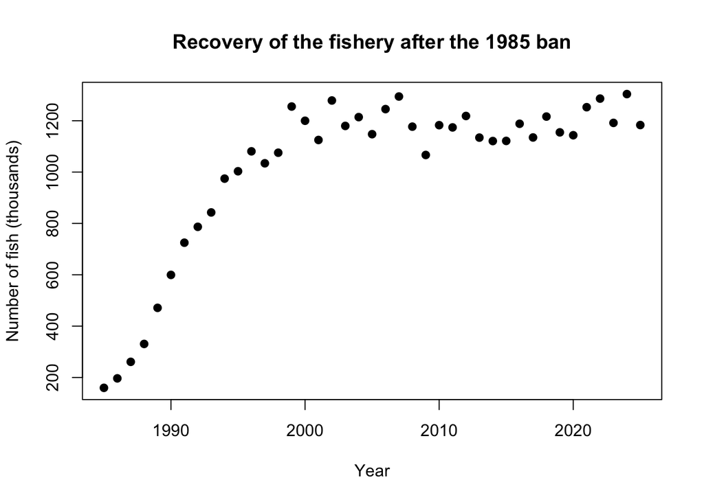

**Fig. 1 -** Total survey estimates for the fishery since fishing was banned in 1985.

```r
# Plot the total stock over time
plot(counts$year, counts$total,
     pch = 19,
     xlab = "Year",
     ylab = "Number of fish (thousands)",
     main = "Recovery of the fishery after the 1985 ban")
```

**In your report:** describe the recovery in a sentence or two, using inline code for the numbers. For example, mine says “Between 1985 and 2025 the stock grew from 159.6 to 1183.2 thousand fish.” and in my `.Rmd` file that sentence looks like this:

```markdown
Between 1985 and 2025 the stock grew from `r N_1985` to `r N_2025` thousand fish.
```

## Estimating the carrying capacity

Look at the plot. The stock grows quickly at first and then levels off. The level at which it plateaus is the carrying capacity `K`, just like the paramecium example last week. To estimate `K`, we take the mean of the surveys once the stock has levelled off. From the plot, that’s from about 2000 onwards. More subsetting! Woohoo!

```r
# Keep only the years after the stock levelled off
plateau <- counts[counts$year >= 2000, ]

# Carrying capacity K: the mean total from those years
K_plateau <- mean(plateau$total)
K_plateau
```

```
## [1] 1189.804
```

The surveys bounce either side of `K` from year to year, which is what we’d expect if the population is sitting at its carrying capacity. At this point, the ups and downs are just good years, bad years and survey error.

**In your report:** add an appropriate heading and explain how you estimated `K`. You might like to mention the carrying capacity you calculated within your text block using inline code. It’s also worth adding `abline(h = K_plateau, lty = 2)` under your recovery plot to show where `K` sits. Remember the chunk that calculates `K` has to come before the plot for this to work so think about how you might present it.

## Estimating R0

Now for the trickier parameter. `R_0` is the per capita growth rate when the population is small or nearly zero. The logistic model says that the per capita growth rate `R` falls in a straight line as the population grows:

$$R = R_0\left(1 -
\frac{N}{K}\right)$$

So if we plot the observed `R` against `N`, the points should fall roughly on a straight line, and where that line hits `N = 0` is `R_0`. This is exactly why the early recovery years are so valuable. They are the only years when the population was small.

Just like last week, we can build a table of observed growth from one year to the next. Notice the negative numbers inside the square brackets. A minus sign means “everything **except** this one”, so `[-n_years]` drops the last year and `[-1]` drops the first.

```r
# Population size this year, N(t). We drop the last year because there is no
# following year to compare it to
N_t <- counts$total[-n_years]     # n_years was calculated in our second code block

# Population size next year, N(t+1). We drop the first year so everything lines up
N_t1 <- counts$total[-1]

# A table of the observed growth from each year to the next
growth <- data.frame(
  year = counts$year[-n_years],
  N = N_t,
  # Observed natural growth G(N). No fishing, so this is just the change in N
  G_obs = N_t1 - N_t,
  # Observed per capita growth rate R = G(N) / N
  R_obs = (N_t1 - N_t) / N_t
)

# This table is 40 lines long, so let's just have a look at the first ten years of the
# recovery, when the population was small
growth[growth$year < 1995, ]
```

```
##    year     N G_obs      R_obs
## 1  1985 159.6  36.9 0.23120301
## 2  1986 196.5  64.4 0.32773537
## 3  1987 260.9  69.7 0.26715217
## 4  1988 330.6 140.6 0.42528736
## 5  1989 471.2 128.3 0.27228353
## 6  1990 599.5 125.4 0.20917431
## 7  1991 724.9  61.9 0.08539109
## 8  1992 786.8  56.0 0.07117438
## 9  1993 842.8 131.7 0.15626483
## 10 1994 974.5  28.7 0.02945100
```

Now we fit a straight line through `R_obs` against `N`. In Excel you would have added a linear trendline to your chart. In R, the line of best fit comes from the function `lm()`, which stands for linear model. The `~` means “explained by”, so `R_obs ~ N` means “R_obs explained by N”.

```r
# Fit a straight line to R_obs against N
fit <- lm(R_obs ~ N, data = growth)

# Have a look at fit to see the value of R0 and slope (confusingly, labelled N by lm())
fit
```

```
##
## Call:
## lm(formula = R_obs ~ N, data = growth)
##
## Coefficients:
## (Intercept)            N
##   0.3944630   -0.0003319
```

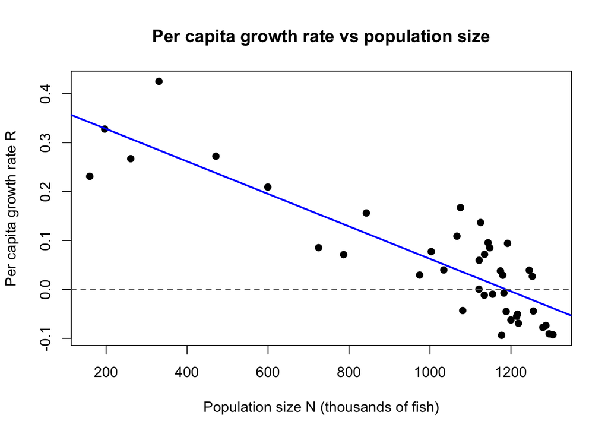

**Fig. 2 -** Observed per capita growth rate against population size, with the line of best fit.

```r
# Plot the observed R against N, with the line of best fit and a line at R = 0
plot(growth$N, growth$R_obs,
     pch = 19,
     xlab = "Population size N (thousands of fish)",
     ylab = "Per capita growth rate R",
     main = "Per capita growth rate vs population size")
abline(fit, col = "blue", lwd = 2)
abline(h = 0, lty = 2, col = "grey40")
```

There’s our straight line, falling as the population grows. The points are noisy (real data always are!), but the trend is clear. The line crosses `R = 0` which we already calculated with `lm()` in addition to the slope. Let’s extract these values so we can use them to calculate K and to compare this to the value we calculated earlier for K as `mean(plateau$total)`.

```r
# This slightly complicated line uses coef() to extract R from fit, unname() to remove
# the (Intercept) heading and [] to subset the first column
R0 <- unname(coef(fit)[1])

# Do the same for slope
slope <- unname(coef(fit)[2])
```

The line falls from R0 at N = 0 to 0 at N = K. Looking at the formula:

$$R = R_0 - \frac{R_0}{K}N$$
we can see that the `slope = -R0/K`. Rearranging this for `K`, we get `K = -R0/slope`. We can use this to calculate K and to then compare it to our original value of K.

```r
# Calculate K based on where the line intersects x axis when per capita growth rate = 0
K_line <- R0/-slope

# Compare it with K from the plateau mean
K_plateau
```

```
## [1] 1189.804
```

```r
K_line
```

```
## [1] 1188.347
```

Not bad.

**In your report:** add a heading `# Estimating R0`, explain how you estimated `R_0` and report it with inline code. Hint, `round(R0, 2)` inside your inline code will stop R giving you 15 decimal places.

## The production function

We now have both parameters, so we can calculate the production function `G(N)` for every population size from 0 to `K`, and plot it. We’ll also add our observed growth, `G_obs`, as points, so we can see how well the model matches the data. Remember the formula for the logistic production function:

$$G(N) = R_0\left(1 -
\frac{N}{K}\right)N$$

```r
# Create a dataframe consisteing of one column N, with values going from 0 to the carrying capacity K in steps of 1
production <- data.frame(N = seq(0, K_line, by = 1))

# Have a look at it so you understand what you did
head(production)
```

```
##   N
## 1 0
## 2 1
## 3 2
## 4 3
## 5 4
## 6 5
```

```r
tail(production)
```

```
##         N
## 1184 1183
## 1185 1184
## 1186 1185
## 1187 1186
## 1188 1187
## 1189 1188
```

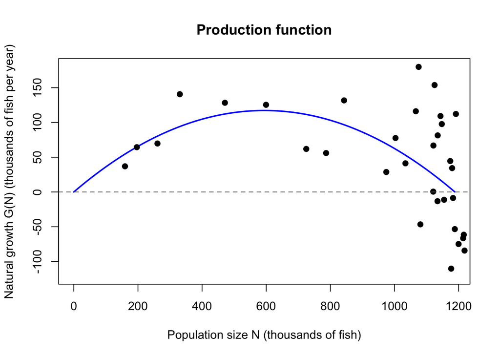

**Fig. 3 -** The logistic production function (line) with the observed growth from each year to the next (points).

```r
# Add a column G_N to your production dataframe to hold the output of the production function calculations
production$G_N <- R0 * (1 - production$N / K_line) * production$N

# Plot the production function as a line
plot(production$N, production$G_N,
     type = "l",
     lwd = 2,
     col = "blue",
     # Make the y axis tall enough to fit all of the observed points
     ylim = range(c(production$G_N, growth$G_obs)),
     xlab = "Population size N (thousands of fish)",
     ylab = "Natural growth G(N) (thousands of fish per year)",
     main = "Production function")

# Add the observed growth as points, and a dashed line at zero
points(growth$N, growth$G_obs, pch = 19)
abline(h = 0, lty = 2, col = "grey40")
```

There’s the hump from the lectures, and the observed growth follows it reasonably well. The peak of the hump is the maximum sustainable yield (MSY), the largest harvest the population could possibly sustain. We can find it with subsetting, by asking for the largest value of `G(N)` in our `production` dataframe, and the population size where it happens. We’ll then check these against the formulas from the lectures, `MSY = R0K/4` and `N_MSY = K/2`.

```r
# The Maximum Sustainable Yield is the largest value of G(N)
MSY <- max(production$G_N)

# The population size where G(N) is at its largest
N_MSY <- production[production$G_N == MSY, "N"]

# Check them against the formulas from the lectures
MSY
```

```
## [1] 117.1898
```

```r
R0 * K_line / 4
```

```
## [1] 117.1898
```

```r
N_MSY
```

```
## [1] 594
```

```r
K_line / 2
```

```
## [1] 594.1736
```

They agree, give or take a tiny amount, because the `N` values in `production` only go up in steps of 1. We use the values from the table rather than the formulas, because the next section subsets the same table. If we used the formula, the MSY would be a tiny bit higher than any value of `G(N)` in the table, and R would think there was no equilibrium at the MSY at all.

**In your report:** add a heading `# The production function`, include the plot, and report the MSY and `N_MSY` using inline code.

## Choosing a sustainable harvest

Now for the question we came here to answer. We’ll compare four possible harvests: half the MSY, three quarters of the MSY, the MSY itself, and a quarter more than the MSY.

```r
# Four harvests to compare, in thousands of fish per year
harvests <- c(0.5, 0.75, 1, 1.25) * MSY
round(harvests)
```

```
## [1]  59  88 117 146
```

### Finding the equilibria

From the lectures, remember that a harvest `h` has an equilibrium wherever `G(N) = h`. On the production function, that’s wherever a horizontal line at `h` crosses the hump. We can find these by subsetting. We keep every population size where natural growth can keep up with the harvest, in other words where `G(N) >= h`, and the two ends of that range are the two equilibria.

We’ll do this for all four harvests at once with a `for loop`, storing the answers in a dataframe. There’s one catch. If a harvest is bigger than the MSY, there are no population sizes that can keep up with it, so the subset has no rows. We use an `if` statement, just like the R version check in Week 2, to only fill in the equilibria when there are some.

```r
# A dataframe to hold the equilibria for each harvest. NA means "not available"
equilibria <- data.frame(h = harvests, lower = NA, upper = NA)

for (i in 1:nrow(equilibria)) {
  # Keep the population sizes where G(N) can keep up with this harvest
  can_sustain <- production[production$G_N >= equilibria$h[i], ]    # This line subsets the production dataframe

  # If there are any, the smallest and largest are the two equilibria
  if (nrow(can_sustain) > 0) {
    equilibria$lower[i] <- min(can_sustain$N)
    equilibria$upper[i] <- max(can_sustain$N)
  }
}

# Check out your equilibria dataframe now, rounding to whole numbers
round(equilibria)
```

```
##     h lower upper
## 1  59   175  1014
## 2  88   298   891
## 3 117   594   594
## 4 146    NA    NA
```

What was all that about? What we did was that we took the `production` dataframe you created above and for every proposed harvest number (59, 88, 117, 146 thousand fish), we subsetted out those rows where G(N) was equal to or greater than the proposed harvest number (`equilibria$h`). To satisfy yourself that you understand this code block, try out `head()` and `tail()` on `production` and `equilibria`. Understanding the input and output data will help you understand how this code for loop and if/then statement works.

Now have a look at the equilibria dataframe again. You’ll notice that when h is equal to half the MSY, the two equilibria are far apart. As the harvest grows, these values squeeze together, until at the MSY they meet at `N_MSY`. Above the MSY there are no values that satisfy our subsetting criteria at all, which means no equilibrium is possible and so a population collapse is inevitable.

### Testing stability

Finding an equilibrium is great, but we also need to know whether our equilibrium is ecologically stable. Just like you did in Excel, we test this by starting the population at different sizes, harvesting it every year, and watching what happens. We’ll try every combination of our four harvests and six starting populations, including today’s stock, over 50 years. `expand.grid()` makes a table of every combination.

```r
# Every combination of six starting populations and our four harvests
scenarios <- expand.grid(N0 = c(200, 400, 600, 800, 1000, N_2025),
                         h = harvests)

scenarios
```

```
##        N0         h
## 1   200.0  58.59488
## 2   400.0  58.59488
## 3   600.0  58.59488
## 4   800.0  58.59488
## 5  1000.0  58.59488
## 6  1183.2  58.59488
## 7   200.0  87.89232
## 8   400.0  87.89232
## 9   600.0  87.89232
## 10  800.0  87.89232
## 11 1000.0  87.89232
## 12 1183.2  87.89232
## 13  200.0 117.18976
## 14  400.0 117.18976
## 15  600.0 117.18976
## 16  800.0 117.18976
## 17 1000.0 117.18976
## 18 1183.2 117.18976
## 19  200.0 146.48720
## 20  400.0 146.48720
## 21  600.0 146.48720
## 22  800.0 146.48720
## 23 1000.0 146.48720
## 24 1183.2 146.48720
```

Now we loop over the rows of `scenarios`. For each one, we step the model forward one year at a time, just like last week, but this time subtracting the harvest using the logistic growth model with harvesting:

$$N_{t+1} = N_t + R_0\left(1 -
\frac{N_t}{K}\right)N_t - h$$

In human speak, next year’s population size `Nt+1` is equal to this year’s population size `Nt` plus the natural growth of the population `G(Nt)` or as it is written here, `R0(1-Nt/K)Nt` minus the harvest `h`.

The final two codeblocks are going to be challenging. We’re going to take these 24 proposed scenarios which invlove unique combinations of starting population size and harvest number, and use them to predict future population growth by applying the logistic growth model with harvesting (formula above). The code is more complicated than you’re really going to need to produce in the third section of this course, but if you can follow the logic behind it, you will know that you really do understand logistic growth models. The whole point of this code block is to set up the simulations dataframe which we will use to plot the growth curves of the six starting populations we have stored in `scenarios`. I know I went on a bit about actually typing code rather than copy pasting it, but for this next bit if you choose to copy paste, you will be forgiven as long as you spend some time slowly reading through the code to try and understand what it’s doing.

One thing to note - a population can’t have fewer than zero fish, so `max(0, ...)` takes whichever is bigger, zero or the new population size. You’ll see this on the logistic growth model line in the next code block. Ok folks, here we go:

```r
# Number of years to simulate
n_sim <- 50

# An empty dataframe to collect every simulation
simulations <- data.frame()

# WARNING: Monstrous looking for loop ahead!
for (i in 1:nrow(scenarios)) {
  # Subset out the starting population and harvest for this scenario
  N0 <- scenarios[i, "N0"]
  h <- scenarios[i, "h"]

  # Step the model forward one year at a time
  N <- numeric(n_sim + 1)
  N[1] <- N0
  for (j in 1:n_sim) {
    N[j + 1] <- max(0, N[j] + R0 * (1 - N[j] / K_line) * N[j] - h)     # This is the logistic growth model with harvesting
  }

  # Stack this simulation onto the bottom of the others
  simulations <- rbind(simulations, data.frame(year = 0:n_sim, N = N, N0 = N0, h = h))
}

# OOF! I'm glad that's over.

# The simulations dataframe is 1224 lines long so just have a look at its head and tail to
# try to understand how this crazy looking nested for loop works
head(simulations)
```

```
##   year        N  N0        h
## 1    0 200.0000 200 58.59488
## 2    1 207.0200 200 58.59488
## 3    2 215.8607 200 58.59488
## 4    3 226.9478 200 58.59488
## 5    4 240.7786 200 58.59488
## 6    5 257.9179 200 58.59488
```

```r
tail(simulations)
```

```
##      year N     N0        h
## 1219   45 0 1183.2 146.4872
## 1220   46 0 1183.2 146.4872
## 1221   47 0 1183.2 146.4872
## 1222   48 0 1183.2 146.4872
## 1223   49 0 1183.2 146.4872
## 1224   50 0 1183.2 146.4872
```

FINAL PLOT AHEAD! Let’s plot the simulations for one harvest value. We subset out the rows for that harvest, draw an empty set of axes with `type = "n"` (n for nothing), and then use a `for loop` to subset out each starting population in turn and then draw it with `lines()`. `paste()` glues bits of text together to make a title that changes with the harvest.

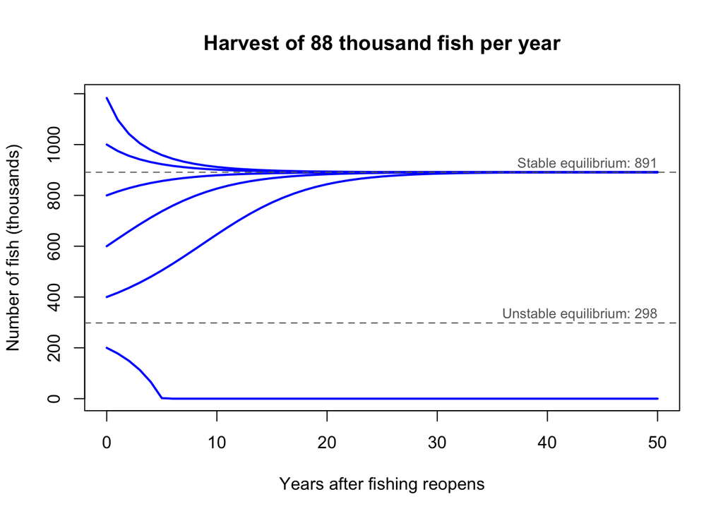

The stock over 50 years from six starting populations, harvesting three quarters of the MSY. The dashed lines are the two equilibria.

```r
# Choose which harvest to plot, the second one (88) is equal to three quarters of the MSY
h_plot <- harvests[2]

# Subset out the simulations and equilibria for that harvest
sims_h <- simulations[simulations$h == h_plot, ]
eq_h <- equilibria[equilibria$h == h_plot, ]

# Draw the axes only
plot(sims_h$year, sims_h$N,
     type = "n",
     ylim = c(0, K_line),
     xlab = "Years after fishing reopens",
     ylab = "Number of fish (thousands)",
     main = paste("Harvest of", round(h_plot), "thousand fish per year"))

# One line for each starting population
for (start in unique(sims_h$N0)) {
  one_run <- sims_h[sims_h$N0 == start, ]
  lines(one_run$year, one_run$N, lwd = 2, col = "blue")
}

# Add the two equilibria as dashed grey lines, and label them
abline(h = c(eq_h$lower, eq_h$upper), lty = 2, col = "grey40")
text(x = n_sim, y = c(eq_h$lower, eq_h$upper),
     labels = paste(c("Unstable", "Stable"), "equilibrium:", round(c(eq_h$lower, eq_h$upper))),
     adj = c(1, -0.5), cex = 0.8, col = "grey40")
```

Done! Looking at the plot you’ll see that every population that started **above** the lower equilibrium ended up at the upper equilibrium, so the upper equilibrium is **stable**. The population that started **below** the lower equilibrium crashed to zero, so the lower equilibrium is **unstable**. That lower equilibrium is a danger line. If the stock ever falls below it, the fishery will collapse unless the harvest is cut.

### Your turn

Copy the plotting chunk three times and change `h_plot` to harvest 1, 3 and 4, so that your report has a plot for all four harvests. What happens at the MSY? What happens above it? Which starting populations collapsed when harvesting three quarters of the MSY? Just a word of warning, if you plot `harvests[3]`, the single equilibrium will get the label `Unstable equilibrium` and `Stable quilibrium` overlaid on top of each other. This is just a quirk of the plotting script we used as in reality, there is only one equilibrium at the MSY and it is unstable.

## Your recommendation

So, how much should the fishery be allowed to harvest? From the lectures and from your own simulations, a harvest is only sustainable if it is **below** the MSY and the stock stays **above** the lower equilibrium. Harvesting right at the MSY isn’t safe, because one bad year that knocks the stock below `N_MSY` is enough to initiate a collapse. And remember, our `K` and `R_0` are only estimates.

**In your report:** under a heading `# Recommendation`, recommend an annual harvest for the fishery, in thousands of fish per year, and justify it using your equilibria and your simulations.

*SC1102 R Bootcamp, James Cook University. Course home*